# Differentially expressed protein analysis of SWATH data using ANOVA testing

This worflow shows how to process data from SWATH-MS protein quantification, in order to study differential expression of the proteins between the different conditions.

The data in this example come from : Bjelosevic S, Pascovici D, Ping H, et.al. Quantitative age-specific variability of plasma proteins in healthy neonates, children and adults. Molecular & Cellular Proteomics (March 23 2017). Four conditions are compared each conditions have ten replicates :  
-neonates  
-child less than one year old  
-child between 1 and five years old  
-adults

146 proteins were identified and quantified.

Here we use ANOVA (analysis of variance) to identify significantly differentially expressed protein. The ANOVA test the statistical significance of the mean difference between several groups. But ANOVA doesn’t allow to identify between exactly which groups this difference is significant that is why a POST HOC test is needed to precise the groups between which the difference is the most significant.

# 1. loading and visualizing the data

```r
data<-read.table("SWATH.example.data.csv", sep=",",header=T, row.names = 1)
data
```

|  | Sample.1 | Sample.2 | Sample.3 | Sample.4 | Sample.5 | Sample.6 | Sample.7 | Sample.8 | Sample.9 | Sample.10 | Sample.11 | Sample.12 | Sample.13 | Sample.14 | Sample.15 | Sample.16 | Sample.17 | Sample.18 | Sample.19 | Sample.20 | Sample.21 | Sample.22 | Sample.23 | Sample.24 | Sample.25 | Sample.26 | Sample.27 | Sample.28 | Sample.29 | … |
| --- | --- | --- | --- | --- | --- | --- | --- | --- | --- | --- | --- | --- | --- | --- | --- | --- | --- | --- | --- | --- | --- | --- | --- | --- | --- | --- | --- | --- | --- | --- |
| sp\|A0M8Q6\|LAC7_HUMAN | 1.115502e+05 | 9.203458e+03 | 6.672549e+04 | 5.991088e+04 | 1.642215e+05 | 9.143973e+03 | 6.409901e+06 | 1.238785e+04 | 7.809981e+03 | 4.553976e+04 | 5.593150e+04 | 3.501655e+04 | 3.254635e+04 | 5.664431e+04 | 1.839196e+04 | 3.113175e+06 | 1.320937e+04 | 1.982661e+04 | 4.225821e+06 | 1.682750e+05 | 2.277252e+06 | 6.397863e+06 | 3.189287e+06 | 3.628608e+06 | 4.121755e+06 | 1.426761e+05 | 4.140672e+06 | 1.802475e+05 | 5.826897e+06 | … |
| sp\|B9A064\|IGLL5_HUMAN | 6.555987e+06 | 7.765069e+06 | 9.187741e+06 | 7.691362e+06 | 1.498776e+07 | 1.374116e+07 | 8.230958e+06 | 8.681886e+06 | 9.058707e+06 | 8.188822e+06 | 2.531991e+06 | 3.934526e+06 | 1.700102e+06 | 4.418838e+06 | 5.584636e+06 | 3.334236e+06 | 3.871055e+06 | 3.312348e+06 | 4.053520e+06 | 4.567918e+06 | 9.331017e+06 | 1.055792e+07 | 6.857038e+06 | 8.977858e+06 | 9.036241e+06 | 1.460044e+07 | 1.090076e+07 | 1.178051e+07 | 9.930735e+06 | … |
| sp\|O14791\|APOL1_HUMAN | 1.001121e+07 | 6.967989e+06 | 8.196725e+06 | 7.793772e+06 | 4.469132e+06 | 2.344268e+05 | 1.072176e+07 | 2.178108e+05 | 1.626200e+05 | 2.884709e+05 | 8.933724e+06 | 8.123464e+05 | 8.198270e+05 | 4.858403e+05 | 6.382900e+05 | 5.737175e+06 | 7.894232e+06 | 7.794366e+06 | 3.373264e+05 | 8.217965e+05 | 1.036517e+06 | 8.268936e+05 | 8.869152e+05 | 1.007503e+06 | 9.127178e+05 | 1.089386e+06 | 7.271341e+05 | 1.024629e+06 | 5.359292e+05 | … |
| sp\|O43866\|CD5L_HUMAN | 8.159506e+04 | 6.204646e+05 | 1.567635e+05 | 2.038546e+05 | 1.109301e+05 | 2.877470e+05 | 6.997967e+04 | 2.019811e+05 | 1.118168e+05 | 1.388014e+05 | 1.591100e+06 | 8.304909e+05 | 1.683988e+06 | 8.369937e+05 | 1.024494e+06 | 1.487672e+06 | 8.896914e+05 | 6.911559e+05 | 7.834091e+05 | 1.137166e+06 | 1.474772e+06 | 3.229527e+06 | 5.422559e+05 | 7.143334e+05 | 1.521902e+06 | 9.076956e+05 | 9.373061e+05 | 1.809989e+06 | 1.370390e+06 | … |
| sp\|O75636\|FCN3_HUMAN | 2.559217e+05 | 3.979038e+05 | 3.513910e+05 | 3.117654e+05 | 3.523802e+05 | 4.164043e+05 | 1.661627e+05 | 1.592014e+05 | 3.600346e+05 | 4.019163e+05 | 6.269995e+05 | 4.309955e+05 | 5.264501e+05 | 3.827408e+05 | 4.612140e+05 | 4.070175e+05 | 4.470716e+05 | 4.385885e+05 | 2.046635e+05 | 3.899665e+05 | 3.983688e+05 | 4.408848e+05 | 3.895040e+05 | 4.880614e+05 | 3.715512e+05 | 2.801026e+05 | 4.840683e+05 | 4.352776e+05 | 3.844813e+05 | … |
| sp\|O75882\|ATRN_HUMAN | 1.767532e+05 | 1.558307e+05 | 1.316840e+05 | 1.857808e+05 | 2.112565e+05 | 2.224510e+05 | 1.410986e+05 | 1.870620e+05 | 1.454212e+05 | 1.771302e+05 | 2.103269e+05 | 1.597351e+05 | 1.954820e+05 | 1.480458e+05 | 2.178803e+05 | 2.424497e+05 | 1.444728e+05 | 2.148264e+05 | 1.355214e+05 | 1.719731e+05 | 2.185981e+05 | 2.668701e+05 | 2.079915e+05 | 4.137703e+05 | 2.058052e+05 | 1.970503e+05 | 1.905642e+05 | 2.319276e+05 | 2.143148e+05 | … |
| sp\|O95445\|APOM_HUMAN | 1.020017e+06 | 2.250939e+06 | 1.349443e+06 | 9.617744e+05 | 1.058482e+06 | 1.818463e+06 | 1.528318e+06 | 1.818339e+06 | 2.021296e+06 | 2.281483e+06 | 2.892953e+06 | 1.650583e+06 | 3.291866e+06 | 2.130070e+06 | 3.015864e+06 | 2.538538e+06 | 1.714518e+06 | 2.612111e+06 | 1.372180e+06 | 1.699907e+06 | 1.902994e+06 | 2.084267e+06 | 2.146561e+06 | 1.596102e+06 | 2.170206e+06 | 2.027062e+06 | 1.920462e+06 | 1.258234e+06 | 2.237601e+06 | … |
| sp\|P00450\|CERU_HUMAN | 1.182729e+07 | 1.821801e+07 | 2.511296e+07 | 3.728021e+07 | 1.543016e+07 | 1.985402e+07 | 2.195637e+07 | 2.699302e+07 | 2.181524e+07 | 1.232113e+07 | 3.956893e+07 | 4.466537e+07 | 3.973772e+07 | 3.389234e+07 | 3.734018e+07 | 3.890265e+07 | 3.234811e+07 | 3.486318e+07 | 3.086611e+07 | 5.164749e+07 | 4.644504e+07 | 4.955205e+07 | 5.197502e+07 | 5.020298e+07 | 4.124388e+07 | 3.203656e+07 | 5.005262e+07 | 5.292072e+07 | 4.146162e+07 | … |
| sp\|P00734\|THRB_HUMAN | 5.268991e+06 | 1.080345e+07 | 1.063795e+07 | 8.633835e+06 | 5.519106e+06 | 1.054838e+07 | 5.367526e+06 | 1.129812e+07 | 1.155138e+07 | 1.037768e+07 | 1.819373e+07 | 1.086306e+07 | 1.516987e+07 | 1.108148e+07 | 1.580313e+07 | 1.372989e+07 | 9.926704e+06 | 1.290357e+07 | 1.302017e+07 | 1.380308e+07 | 1.234260e+07 | 1.385705e+07 | 1.472569e+07 | 1.725223e+07 | 1.378623e+07 | 1.082918e+07 | 1.498588e+07 | 1.708767e+07 | 1.292654e+07 | … |
| sp\|P00736\|C1R_HUMAN | 7.147036e+05 | 6.590983e+05 | 7.095505e+05 | 9.111163e+05 | 7.567476e+05 | 1.142857e+06 | 7.139793e+05 | 9.441301e+05 | 9.327809e+05 | 6.085300e+05 | 4.710490e+05 | 6.094145e+05 | 6.985228e+05 | 5.892876e+05 | 8.123817e+05 | 7.464940e+05 | 8.176705e+05 | 7.110055e+05 | 7.786733e+05 | 7.298765e+05 | 8.178142e+05 | 6.087981e+05 | 8.432841e+05 | 8.864449e+05 | 9.095868e+05 | 7.560945e+05 | 6.876085e+05 | 9.026293e+05 | 5.807046e+05 | … |

[output cut: 136 more lines]

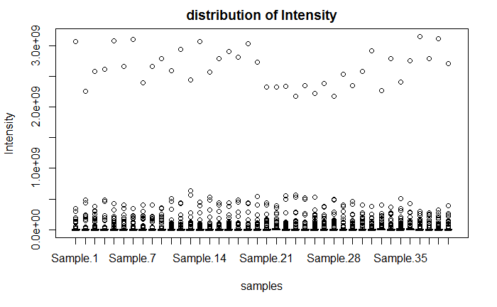

```r
boxplot(data, ylab="Intensity", xlab="samples", main = "distribution of Intensity")
```

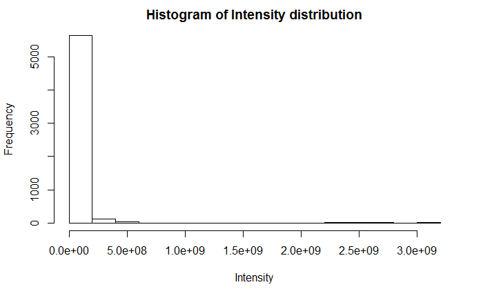

```r
hist(as.numeric(unlist(data)), main = "Histogram of Intensity distribution",  xlab = "Intensity")
```

# 2. log transform

The data is log transformed so that:  
-the spread is even across the intensity range  
-the variability stays constant at all intensity levels  
-the distribution of experimental errors is normal  
-the distribution of intensity is bell shaped

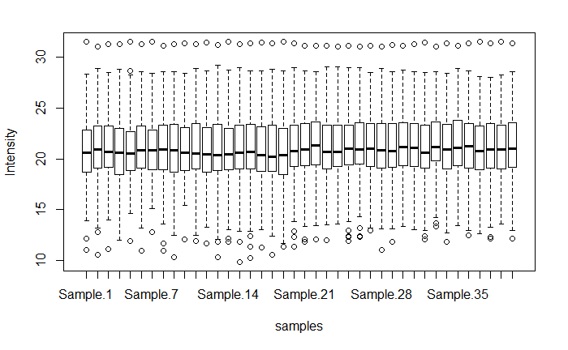

```r
data <- log2(data)
boxplot(data, ylab="Intensity", xlab="samples")
```

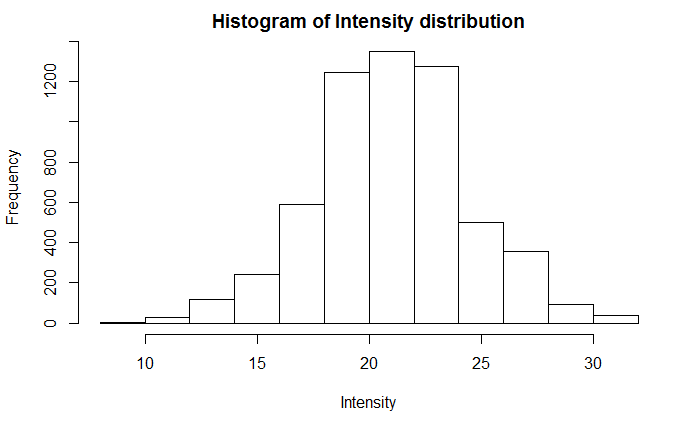

```r
hist(as.numeric(unlist(data)), main = "Histogram of Intensity distribution",  xlab = "Intensity")
```

# 3. Normalization

Normalization allows to resolve the bias and errors introduced between the samples by the experimental tools or the samples preparation. Normalization relies on the fact that most of the proteins are expected to be expressed the same way between the samples, so it is necessary to remove the differences induced by the experiment to not overestimate the differencial expression. here we use the mean center and scaling normalization : centering assure that the mean of the different samples is equal (set to 0), and scaling sets the standard deviation to 1.

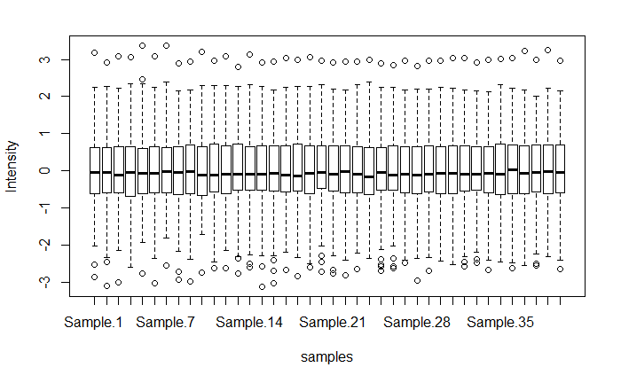

```r
norm.data <- scale(data) ##mean center and scaling normalization
boxplot(norm.data, ylab="Intensity", xlab="samples")
```

# 4. Differential expression annalysis

## 4.1 ANOVA test

The type of ANOVA test to perform is a one-way ANOVA on each protein.

```r
Results <- as.data.frame(norm.data)
## Calcul of the mean Intensity for each conditions :
Results$control <- rowMeans(norm.data[, c(1:10)])
Results$less1 <- rowMeans(norm.data[, c(11:20)])
Results$onetofive <- rowMeans(norm.data[, c(21:30)])
Results$adult <- rowMeans(norm.data[, c(31:40)])
Results <- Results[, c(41, 42, 43, 44)]
d <- data.frame(mean = 1:40, group = 1:40)
for (i in 1:nrow(norm.data)) {
  d$mean <- as.numeric(norm.data[i, ])
  d$group[1:10] <- "control"
  d$group[11:20] <- "less1"
  d$group[21:30] <- "onetofive"
  d$group[31:40] <- "adult"
  model <- lm(formula = mean ~ group, data = d)
  Results$p[i] <- anova(model)$"Pr(>F)"
  Results$p[i] <- p.adjust(Results$p[i], method = "BH") ## multiple testing correction with de Benjamini Hochberg technique
  # print(TukeyHSD(aov(mean ~ group, data = d)))
}
```

## 4.3 Differentially expressed proteins

Calcul of the maximum fold change for each protein (difference between the highest and the lowest intensity mean) :

```r
Results$FC <-apply(Results[, 1:4], 1, max) - apply(Results[, 1:4], 1, min)
Results
```

|  | control | less1 | onetofive | adult | p | FC |
| --- | --- | --- | --- | --- | --- | --- |
| sp\|A0M8Q6\|LAC7_HUMAN | -1.54947333 | -1.232470819 | -0.072835844 | 0.08170746 | 1.695041e-05 | 1.63118079 |
| sp\|B9A064\|IGLL5_HUMAN | 0.65312105 | 0.267869540 | 0.587181433 | 0.66907049 | 5.576046e-09 | 0.40120095 |
| sp\|O14791\|APOL1_HUMAN | -0.02331559 | -0.040072869 | -0.454936510 | 0.05015140 | 1.745310e-01 | 0.50508791 |
| sp\|O43866\|CD5L_HUMAN | -1.09537667 | -0.235899966 | -0.298648910 | -0.25744238 | 1.165578e-12 | 0.85947670 |
| sp\|O75636\|FCN3_HUMAN | -0.81960858 | -0.610067908 | -0.769136025 | -0.95860889 | 9.127888e-07 | 0.34854099 |
| sp\|O75882\|ATRN_HUMAN | -1.06411479 | -0.952232008 | -1.016684262 | -1.15169423 | 1.269995e-04 | 0.19946222 |
| sp\|O95445\|APOM_HUMAN | -0.11734216 | 0.068255335 | -0.116348377 | -0.21010491 | 3.213641e-06 | 0.27836025 |
| sp\|P00450\|CERU_HUMAN | 0.98817135 | 1.232421829 | 1.250243683 | 1.13116980 | 2.477310e-05 | 0.26207233 |
| sp\|P00734\|THRB_HUMAN | 0.62436615 | 0.801695906 | 0.748799137 | 0.68271515 | 8.526558e-06 | 0.17732976 |
| sp\|P00736\|C1R_HUMAN | -0.40232131 | -0.406530459 | -0.509216931 | -0.57199331 | 3.747170e-04 | 0.16967200 |

[output cut: 136 more lines]

```r
resultsANOVA <-Results[which(Results$p <= 0.05 & abs(Results$FC) >= 0.5), ]
resultsANOVA
```

|  | control | less1 | onetofive | adult | p | FC |
| --- | --- | --- | --- | --- | --- | --- |
| sp\|A0M8Q6\|LAC7_HUMAN | -1.54947333 | -1.2324708 | -0.07283584 | 0.08170746 | 1.695041e-05 | 1.6311808 |
| sp\|O43866\|CD5L_HUMAN | -1.09537667 | -0.2359000 | -0.29864891 | -0.25744238 | 1.165578e-12 | 0.8594767 |
| sp\|P00738\|HPT_HUMAN | 0.69360902 | 1.4805354 | 1.61821485 | 1.38774536 | 4.037556e-06 | 0.9246058 |
| sp\|P01591\|IGJ_HUMAN | -1.16872376 | -0.3559130 | -0.34245203 | -0.12719816 | 1.162615e-16 | 1.0415256 |
| sp\|P01772\|HV311_HUMAN | -0.75592433 | -1.4492802 | -1.06794005 | -0.79313484 | 1.575544e-09 | 0.6933558 |
| sp\|P01780\|HV319_HUMAN | -1.22552648 | -1.9068723 | -1.34492029 | -1.19477587 | 6.994626e-07 | 0.7120965 |
| sp\|P01834\|IGKC_HUMAN | 1.99671777 | 1.4765074 | 1.73292446 | 1.99509066 | 8.324184e-14 | 0.5202104 |
| sp\|P01859\|IGHG2_HUMAN | 0.69766241 | 0.2132176 | 0.28007486 | 0.80126278 | 8.074156e-17 | 0.5880452 |
| sp\|P01861\|IGHG4_HUMAN | 0.36560745 | -0.3176085 | -0.04174314 | 0.41418356 | 4.213182e-06 | 0.7317921 |
| sp\|P01871\|IGHM_HUMAN | -0.13154265 | 0.6718478 | 0.67061689 | 0.75684028 | 5.021381e-14 | 0.8883829 |

[output cut: 21 more lines]

## 4.4 post hoc analysis

The post hoc analysis is done using the tukey’s test to determine the significants pairwise comparisons.

```r
DEprot <- as.data.frame(data[which(row.names(data) %in% row.names(resultsANOVA)),])
d <- data.frame(mean = 1:40, group = 1:40)
for (i in 1:nrow(DEprot)) {
  d$mean <- as.numeric(DEprot[i, ])
  d$group[1:10] <- "control"
  d$group[11:20] <- "less1"
  d$group[21:30] <- "onetofive"
  d$group[31:40] <- "adult"
  print(paste0(row.names(DEprot[i,]), " :"))
  print(TukeyHSD(aov(mean ~ group, data = d)))
}
```

```
[1] "sp|A0M8Q6|LAC7_HUMAN :"
  Tukey multiple comparisons of means
    95% family-wise confidence level

Fit: aov(formula = mean ~ group, data = d)

$group
                        diff       lwr       upr     p adj
control-adult     -5.7901321 -8.871597 -2.708667 0.0000713
less1-adult       -5.0112034 -8.092668 -1.929739 0.0005470
onetofive-adult   -0.5005643 -3.582029  2.580901 0.9715746
less1-control      0.7789287 -2.302536  3.860394 0.9037156
onetofive-control  5.2895678  2.208103  8.371033 0.0002661
onetofive-less1    4.5106391  1.429174  7.592104 0.0019395

[1] "sp|O43866|CD5L_HUMAN :"
  Tukey multiple comparisons of means
    95% family-wise confidence level

Fit: aov(formula = mean ~ group, data = d)

$group
                         diff        lwr        upr     p adj
control-adult     -3.01848339 -3.8540813 -2.1828854 0.0000000
less1-adult       -0.31524837 -1.1508463  0.5203496 0.7411622
onetofive-adult   -0.07232455 -0.9079225  0.7632734 0.9954573
less1-control      2.70323502  1.8676371  3.5388330 0.0000000
onetofive-control  2.94615884  2.1105609  3.7817568 0.0000000
onetofive-less1    0.24292382 -0.5926741  1.0785218 0.8616696

[1] "sp|P00738|HPT_HUMAN :"
  Tukey multiple comparisons of means
    95% family-wise confidence level

Fit: aov(formula = mean ~ group, data = d)

$group
                        diff        lwr       upr     p adj
control-adult     -2.5714212 -4.0761936 -1.066649 0.0002831
less1-adult        0.2175037 -1.2872687  1.722276 0.9796537
```

[output cut: 409 more lines]

```

[1] "sp|Q9Y490|TLN1_HUMAN :"
  Tukey multiple comparisons of means
    95% family-wise confidence level

Fit: aov(formula = mean ~ group, data = d)

$group
                        diff         lwr        upr     p adj
control-adult     -2.2272064 -3.20131886 -1.2530940 0.0000025
less1-adult       -2.4174355 -3.39154789 -1.4433230 0.0000005
onetofive-adult   -1.3546933 -2.32880569 -0.3805808 0.0033727
less1-control     -0.1902290 -1.16434145  0.7838834 0.9522516
onetofive-control  0.8725132 -0.10159926  1.8466256 0.0927677
onetofive-less1    1.0627422  0.08862977  2.0368546 0.0280067
```

```r
heat <- as.matrix(data[which(row.names(data) %in% row.names(resultsANOVA)),])
```

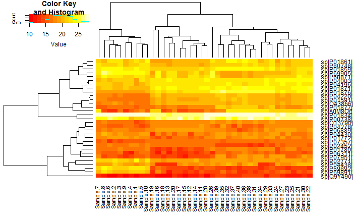

```r
library(gplots)
heatmap.2(heat, trace = "none")
```

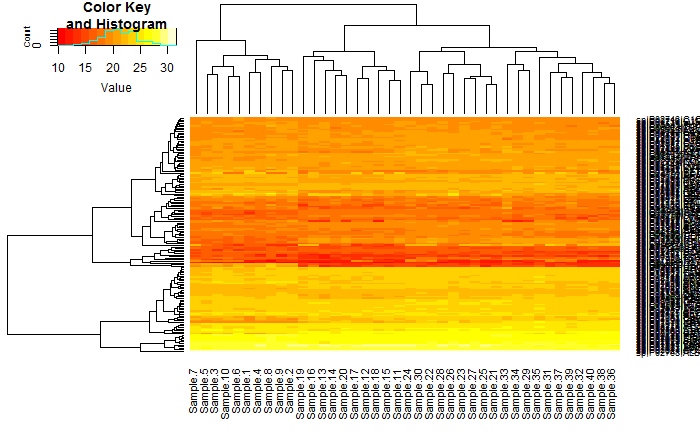

```r
heatmap.2(as.matrix(data), trace = "none")
```

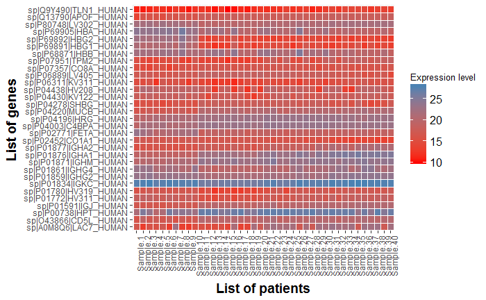

```r
library(reshape2)
heat <- melt(heat)
names(heat) <- c("protein", "sample", "value")
library(ggplot2)
ggplot(heat, aes(sample, protein )) +
  geom_tile(aes(fill = value), color = "white") +
  scale_fill_gradient(low = "red", high = "steelblue") +
  ylab("List of genes ") +
  xlab("List of patients") +
  theme(legend.title = element_text(size = 10),
        legend.text = element_text(size = 12),
        plot.title = element_text(size=16),
        axis.title=element_text(size=14,face="bold"),
        axis.text.x = element_text(angle = 90, hjust = 1)) +
  labs(fill = "Expression level")
```

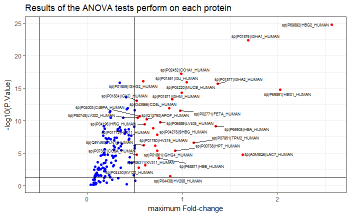

```r
  plotTitle <- "Results of the ANOVA tests perform on each protein"
  values <- as.data.frame(Results)
  forplot <- data.frame(x=as.numeric(values[,6]), y=-log10(values[,5]), id=row.names(values))
  tmp <- forplot[as.numeric(forplot$y)>=-log10(tresh_fc) & abs(forplot$x)>tresh_fc,]
  p <- ggplot(forplot) + geom_point(aes(x, y , color = ifelse(y>=-log10(tresh_p) & abs(x)>=tresh_fc, "not signi", "FC")),show.legend = F) +
    scale_color_manual(values = c("blue", "red")) +
    geom_text_repel(data = subset(forplot, abs(forplot$x)>=tresh_fc & forplot$y>=-log10(tresh_p)),
                    aes(x,y,label = id),
                    size = 2) +
    geom_vline(xintercept = tresh_fc ) +
    geom_vline(xintercept = -tresh_fc) +
    geom_hline(yintercept = -log10(tresh_p)) +
    labs(title = plotTitle,x="maximum Fold-change", y="-log10(P.Value)") + theme_bw()
    print(p)
```

```r
res <- row.names(resultsANOVA)
print(res)
```

```
 [1] "sp|A0M8Q6|LAC7_HUMAN"  "sp|O43866|CD5L_HUMAN"  "sp|P00738|HPT_HUMAN"   "sp|P01591|IGJ_HUMAN"
 [5] "sp|P01772|HV311_HUMAN" "sp|P01780|HV319_HUMAN" "sp|P01834|IGKC_HUMAN"  "sp|P01859|IGHG2_HUMAN"
 [9] "sp|P01861|IGHG4_HUMAN" "sp|P01871|IGHM_HUMAN"  "sp|P01876|IGHA1_HUMAN" "sp|P01877|IGHA2_HUMAN"
[13] "sp|P02452|CO1A1_HUMAN" "sp|P02771|FETA_HUMAN"  "sp|P04003|C4BPA_HUMAN" "sp|P04196|HRG_HUMAN"
[17] "sp|P04220|MUCB_HUMAN"  "sp|P04278|SHBG_HUMAN"  "sp|P04430|KV122_HUMAN" "sp|P04438|HV208_HUMAN"
[21] "sp|P06311|KV311_HUMAN" "sp|P06889|LV405_HUMAN" "sp|P07357|CO8A_HUMAN"  "sp|P07951|TPM2_HUMAN"
[25] "sp|P68871|HBB_HUMAN"   "sp|P69891|HBG1_HUMAN"  "sp|P69892|HBG2_HUMAN"  "sp|P69905|HBA_HUMAN"
[29] "sp|P80748|LV302_HUMAN" "sp|Q13790|APOF_HUMAN"  "sp|Q9Y490|TLN1_HUMAN"
```

```r
saveRDS(res, "resANOVA.rds")
```